# SALARY GAP ANALYSIS

The dataset was obtained from kaggle and focuses only on Data related jobs and the salaries all round the world in the years 2020-2024. Following are some of the columns that I will be focussing on for the analysis and attempt to derive some insights:

- job_title
- experience_level
- employment_type
- work_models
- employee_residence
- salary_in_usd
- company_size

### Aim of the Analysis

- The analysis aims to find insights on the impact of several factors like experience level, company size, work models, job title etc on the salary.
- In addition to this, I will also be trying to predict the salary based on other factors based on which ones correlate the most.

## Questions that the analysis aims to answer

- How do different work models affect salary? Does on-site workers get paid more?
- What are the top highest paid job title?
- Does company size affect the pay especially at different experience level?
- Can we come up with a model to predict salary based on some the factors that correlate with the salary column?
- For on-site workers, which area of residence offers the highest salary?

## Importing libraries and reading the file

```python
import pandas as pd
import numpy as np
import seaborn as sns
import matplotlib.pyplot as plt
import scipy.linalg
```

```python
salary = pd.read_csv('data_science_salaries.csv')
```

#### Basic stats and a preview of the dataframe

```python
print(salary.head()) # preview the data
print(salary.describe())
```

```
        job_title experience_level employment_type work_models  work_year  \
0   Data Engineer        Mid-level       Full-time      Remote       2024
1   Data Engineer        Mid-level       Full-time      Remote       2024
2  Data Scientist     Senior-level       Full-time      Remote       2024
3  Data Scientist     Senior-level       Full-time      Remote       2024
4    BI Developer        Mid-level       Full-time     On-site       2024

  employee_residence  salary salary_currency  salary_in_usd company_location  \
0      United States  148100             USD         148100    United States
1      United States   98700             USD          98700    United States
2      United States  140032             USD         140032    United States
3      United States  100022             USD         100022    United States
4      United States  120000             USD         120000    United States

  company_size
0       Medium
1       Medium
2       Medium
3       Medium
4       Medium
         work_year        salary  salary_in_usd
count  6599.000000  6.599000e+03    6599.000000
mean   2022.818457  1.792833e+05  145560.558569
std       0.674809  5.263722e+05   70946.838070
min    2020.000000  1.400000e+04   15000.000000
25%    2023.000000  9.600000e+04   95000.000000
50%    2023.000000  1.400000e+05  138666.000000
75%    2023.000000  1.875000e+05  185000.000000
max    2024.000000  3.040000e+07  750000.000000
```

## A. Data cleaning

Here are the data cleaning steps that I am going to perform:

- Renaming the salary_in_usd column as salary and salry column as salary_in_country as we will be using the usd salary equivalents to maintain consistency in our analysis
- Check for missing values in the salary(usd) column and remove them.
- Check for unique values in experience_level, work_models and company_size columns and encode them to numerical levels to perform further statistical analysis

```python
# Rename salary_in_usd column and salary column to salary_in_country
salary = salary.rename(columns={'salary':'salary_in_country'})
salary = salary.rename(columns={'salary_in_usd':'salary'})
# Check for missing values in columns
print(salary.isna().sum())
# Checking unique values in salary_curreny column
print(salary['salary_currency'].unique())
# Check for duplicated rows
print(salary.duplicated().sum())
```

```
job_title             0
experience_level      0
employment_type       0
work_models           0
work_year             0
employee_residence    0
salary_in_country     0
salary_currency       0
salary                0
company_location      0
company_size          0
dtype: int64
['USD' 'GBP' 'EUR' 'TRY' 'THB' 'ZAR' 'SGD' 'INR' 'PLN' 'PHP' 'NOK' 'ILS'
 'HKD' 'AUD' 'CHF' 'CAD' 'BRL' 'JPY' 'HUF' 'DKK' 'CLP' 'MXN']
0
```

- It looks like there are no null values in any of the columns or duplicate values

#### Encoding columns:experience_levels,work_models and company_size to numerical values

```python
############################################################################################
# experience level encoding

# Check for unique values in experience_level and encode them to numerical levels
print(salary['experience_level'].unique())

# Dictionary for mapping experience levels to numerical values
experience_map = {
    'Entry-level': 0,
    'Mid-level': 1,
    'Senior-level': 2,
    'Executive-level': 3
}

# Create the new column with the mapped values

salary['experience_level_encoded'] = salary['experience_level'].map(experience_map)
print('Experience level encoded:')
print(salary['experience_level_encoded'].unique())

############################################################################################
# company size encoding

size_map = {
    'Small': 1,
    'Medium': 2,
    'Large': 3
}
# Create the new column with the mapped values

salary['company_size_encoded'] = salary['company_size'].map(size_map)
print('Company size encoded:')
print(salary['company_size_encoded'].unique())

############################################################################################
# work models encoding

model_map = {
    'Remote': 1,
    'Hybrid': 0,
    'On-site': 2
}
# Create the new column with the mapped values

salary['work_models_encoded'] = salary['work_models'].map(model_map)
print('Work models encoded:')
print(salary['work_models_encoded'].unique())
```

```
['Mid-level' 'Senior-level' 'Entry-level' 'Executive-level']
Experience level encoded:
[1 2 0 3]
Company size encoded:
[2 3 1]
Work models encoded:
[1 2 0]
```

#### Cleaning up job_title column

```python
print(salary['job_title'].nunique())
```

```
132
```

- There are 132 job titles with a lot of overlaps and lacks standardization.
- We can bring down the number of different kinds of job titles to a few.

```python
def standardize_title(x):
    if 'BI' in x or 'Visualization' in x or 'Business Intelligence' in x:
        return('BI developer')
    elif 'Data Engineer' in x or 'ETL' in x or 'Data DevOps Engineer' in x:
        return('Data Engineer')
    elif 'Data Scientist' in x or 'Data Science' in x:
        return('Data Scientist')
    elif 'AI' in x:
        return('AI Engineer')
    elif 'ML' in x or 'Machine' in x or 'Deep Learning' in x or 'NLP' in x:
        return('Machine Learning Engineer')
    elif 'Data Analyst' in x or 'Data Analytics' in x:
        return('Data Analyst')
    elif 'Data Architect' in x:
        return('Data Architect')
    elif 'Data Operations' in x:
        return('Data Operations')
    elif 'Management' in x or 'Manager' in x:
        return('Data Manager')
    elif 'Computer Vision' in x:
        return('Computer Vision Software Engineer')
    elif 'Research' in x:
        return('Research Engineer/Analyst/Scientist')

    else:
        return(x)
salary['std_job_title'] = salary['job_title'].apply(standardize_title)
print(salary['std_job_title'].unique())
```

```
['Data Engineer' 'Data Scientist' 'BI developer'
 'Research Engineer/Analyst/Scientist' 'Data Analyst'
 'Machine Learning Engineer' 'Applied Scientist' 'Analytics Engineer'
 'AI Engineer' 'Data Specialist' 'Data Architect'
 'Computer Vision Software Engineer' 'Data Lead' 'Data Developer'
 'Data Modeler' 'Data Manager' 'Data Quality Analyst' 'Data Strategist'
 'Prompt Engineer' 'Data Integration Engineer' 'Head of Data'
 'Data Integration Specialist' 'Data Quality Engineer'
 'Decision Scientist' 'Data Infrastructure Engineer' 'Data Operations'
 'Cloud Database Engineer' 'Insight Analyst' 'Data Product Owner'
 'Data Modeller' 'Autonomous Vehicle Technician']
```

```python
print(salary['std_job_title'].nunique())
```

```
31
```

- Now we have reduced the number of job titles to 31 from 132

## B. The Analysis

#### Top 10 and Bottom 10 high paying job titles

```python
grouped = salary.groupby('std_job_title')['salary'].mean().reset_index()
top_n = grouped.nlargest(10,'salary',keep="all").sort_values(by='salary',ascending=False).reset_index(drop=True)
print(top_n)
bottom_n = grouped.nsmallest(10,'salary',keep="all").sort_values(by='salary',ascending=True).reset_index(drop=True)
print(bottom_n)
```

```
                         std_job_title         salary
0         Data Infrastructure Engineer  201375.416667
1                         Head of Data  194412.000000
2                    Applied Scientist  190687.711340
3                            Data Lead  176250.000000
4            Machine Learning Engineer  174970.041280
5  Research Engineer/Analyst/Scientist  169550.293532
6                      Prompt Engineer  166500.000000
7                       Data Architect  163531.823204
8                   Decision Scientist  159445.846154
9                   Analytics Engineer  156336.837398
                   std_job_title         salary
0                Insight Analyst   46339.833333
1             Data Product Owner   80115.500000
2  Autonomous Vehicle Technician   82777.500000
3           Data Quality Analyst   82863.000000
4                  Data Modeller   83052.000000
5    Data Integration Specialist   94516.625000
6          Data Quality Engineer   95584.333333
7                Data Specialist   96261.446809
8                 Data Developer  103030.642857
9                   Data Analyst  106668.131213
```

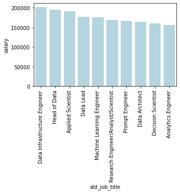

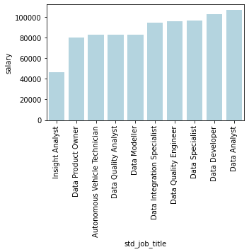

```python
# Salaries by job title
plt.figure(figsize=(5, 3))  # Adjust the figure size if needed
sns.barplot(x="std_job_title", y="salary", data=top_n , color='lightblue')

# Rotate x-axis labels by 45 degrees
plt.xticks(rotation=90)  # You can change the angle as needed (e.g., 45, 90)

# Show the plot
plt.show()

# Salaries by job title
plt.figure(figsize=(5, 3))  # Adjust the figure size if needed
sns.barplot(x="std_job_title", y="salary", data=bottom_n , color='lightblue')

# Rotate x-axis labels by 45 degrees
plt.xticks(rotation=90)  # You can change the angle as needed (e.g., 45, 90)

# Show the plot
plt.show()
```

- An ML Engineer, Data scientist, Architects earn more than a Data Quality technichians or Data analyst

#### Impact of Company size on salaries at various experience levels

```python
size_level = salary.groupby(['company_size','experience_level'])['salary'].mean()
print(size_level)
```

```
company_size  experience_level
Large         Entry-level          74603.330435
              Executive-level     187993.900000
              Mid-level           100625.171271
              Senior-level        150556.660079
Medium        Entry-level          89223.052369
              Executive-level     190563.402655
              Mid-level           123303.988827
              Senior-level        163532.470666
Small         Entry-level          68485.938776
              Executive-level     169172.375000
              Mid-level            73769.645161
              Senior-level        110273.725490
Name: salary, dtype: float64
```

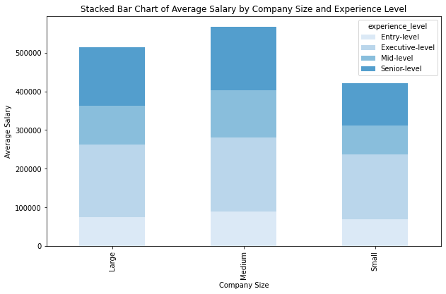

```python
stacked_data = size_level.unstack(fill_value=0)
sns.set_palette("Blues")
stacked_data.plot(kind='bar', stacked=True, figsize=(10, 6))

# Add labels and title
plt.xlabel('Company Size')
plt.ylabel('Average Salary')
plt.title('Stacked Bar Chart of Average Salary by Company Size and Experience Level')

# Show the plot
plt.show()
```

- Overall it looks like in general the salaries of all levels of employees are greater in a company that is Medium size for Entry, Mid-level and senior level and about the same for "Executive level"

#### Countries paying top salaries for Data jobs for On-site workers in USD

```python
salary_onsite = salary[salary['work_models'] == 'On-site']

location_grouped = salary_onsite.groupby(['employee_residence'])['salary'].mean().reset_index()
Top_locations = location_grouped.sort_values(by='salary',ascending=False).head(5).reset_index(drop=True)
Bottom_locations = location_grouped.sort_values(by='salary',ascending=True).head(5).reset_index(drop=True)
display(Top_locations)
display(Bottom_locations)
```

|  | employee_residence | salary |
| --- | --- | --- |
| 0 | Israel | 417937.000000 |
| 1 | Japan | 214000.000000 |
| 2 | New Zealand | 164951.500000 |
| 3 | United States | 159901.829313 |
| 4 | Egypt | 152650.000000 |

|  | employee_residence | salary |
| --- | --- | --- |
| 0 | Indonesia | 15000.0 |
| 1 | Moldova | 18000.0 |
| 2 | Brazil | 18907.0 |
| 3 | Honduras | 20000.0 |
| 4 | Pakistan | 20000.0 |

- On an average countries like Israel, Japan, New Zealand, United States pay top salaries for On-site workers.
- On an average countried like Indonesia, Maldova pay lower for On-site workers.

#### How has the salary for data related jobs grown over the years?

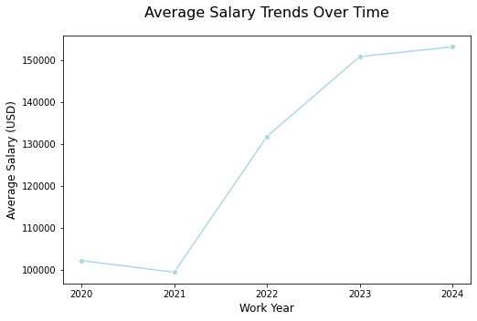

```python
# Create the line plot
plt.figure(figsize=(8, 5))
sns.lineplot(
    x="work_year",
    y="salary",
    color = 'lightblue',
    data=salary,
    marker="o",
    errorbar=None
)

# Customize labels and title
plt.title("Average Salary Trends Over Time", fontsize=16, pad=20)
plt.xlabel("Work Year", fontsize=12)
plt.ylabel("Average Salary (USD)", fontsize=12)
plt.xticks(ticks=[2020, 2021, 2022, 2023,2024])

# Show plot
plt.show()
```

- It looks like there was a slight dip in the salary in the year 2021, otherwise the salary for data jobs has been on the rise!

#### Is there a bias in salary for On-site Vs Remote Vs Hybrid workers?

```python
salary.groupby(['work_models'])['salary'].mean()
```

```
work_models
Hybrid      83293.502222
On-site    152600.100970
Remote     140550.137837
Name: salary, dtype: float64
```

- We can see that On-site and Remote workers nearly get paid double the salary on an average when compared tp Hybrid workers.
- Let us find the salary gap between Remote+On-site workers and Hybrid workers.

#### Salary Gap between Onsite+Remote workers and Hybrid workers

'Remote': 1, 'Hybrid': 0, 'On-site': 2

```python
Remote_Onsite = salary[(salary['work_models_encoded'] == 2) | (salary['work_models_encoded'] == 1)]['salary'].mean()
Hybrid = salary[salary['work_models_encoded'] == 0]['salary'].mean()
gap = ((Remote_Onsite-Hybrid)/Remote_Onsite)*100
print(f"Salary Gap (On-site/Remote vs. Hybrid): {gap:.2f}%")
```

```
Salary Gap (On-site/Remote vs. Hybrid): 43.63%
```

```python
Onsite = salary[(salary['work_models_encoded'] == 2)]['salary'].mean()
Hybrid = salary[salary['work_models_encoded'] == 0]['salary'].mean()
gap = ((Onsite-Hybrid)/Onsite)*100
print(f"Salary Gap (On-site vs. Hybrid): {gap:.2f}%")
```

```
Salary Gap (On-site vs. Hybrid): 45.42%
```

```python
Onsite = salary[(salary['work_models_encoded'] == 2)]['salary'].mean()
Remote = salary[salary['work_models_encoded'] == 1]['salary'].mean()
gap = ((Onsite-Remote)/Onsite)*100
print(f"Salary Gap (On-site vs. Remote): {gap:.2f}%")
```

```
Salary Gap (On-site vs. Remote): 7.90%
```

```python
Remote = salary[(salary['work_models_encoded'] == 1)]['salary'].mean()
Hybrid = salary[salary['work_models_encoded'] == 0]['salary'].mean()
gap = ((Remote-Hybrid)/Remote)*100
print(f"Salary Gap (Remote vs. Hybrid): {gap:.2f}%")
```

```
Salary Gap (Remote vs. Hybrid): 40.74%
```

- As we can see, there is a salary gap between Hybrid workers and Onsite and/or remote workers.
- There is not ahuge salary gap between Onsite and Remote workers.
- It does look like Hybrid workers are paid lesser than Onsite or Remote workers as per the dataset
- In order to build a predictive model, we would like to look at the correlation between the numerically encoded variables and the salary
- Let us build a heatmap to to depict the correlation between the numerical variables

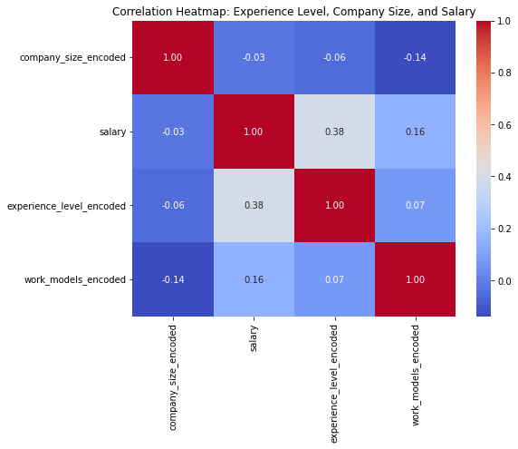

```python
df = salary[['company_size_encoded','salary','experience_level_encoded','work_models_encoded']]
# Calculate correlation matrix
correlation_matrix = df.corr()
# Create a heatmap to visualize the correlation matrix
plt.figure(figsize=(8, 6))
sns.heatmap(correlation_matrix, annot=True, cmap='coolwarm', fmt='.2f', cbar=True)
plt.title('Correlation Heatmap: Experience Level, Company Size, and Salary')
plt.show()
```

- There seems to be some correlation between salary and experience level which is natural.
- Even though we thought that the work models might have some influence on what salary a data individual gets paid, statistics suggests that there is only little orrelation!

## C. Predictive Analysis using Regression

```python
# Constructing X matrix with just two predictors namely company_size_encode and experience_level_encoded
X = df[['company_size_encoded', 'experience_level_encoded','work_models_encoded']]

# Convert to numpy array (optional)
X = X.values
X = np.column_stack([np.ones(len(X)), X])  # Add intercept column
# Constructiong vector of y-values with salary
y = np.array(df['salary'])
```

```python
# QR decomposition of X
Q, R = np.linalg.qr(X)
from scipy.linalg import solve_triangular
#Use  formula Rtheta = Q.Ty
b = Q.T.dot(y)
theta = solve_triangular(R, b)
print(theta)
```

```
[54275.45261147  2309.79114552 38034.4848897  16298.32368613]
```

#### Example prediction

```python
def predict_salary(company_size, experience, work_model):
    theta = [54275.45261147   , 2309.79114552 ,38034.4848897 , 16298.32368613]  # [Intercept, theta1,2,3]
    return theta[0] + theta[1] * company_size + theta[2] * experience + theta[3] * work_model

# Example prediction: Medium company (2), Mid-level (1), Remote (1)
salary_prediction = round(predict_salary(2, 1, 1),3)
print(f"For a Medium company size, a Mid-level employee doing remote work, our model predicts that their salary will be: ${salary_prediction}" )
```

```
For a Medium company size, a Mid-level employee doing remote work, our model predicts that their salary will be: $113227.843
```

## D. Conclusion

Following are the insights we derived by analysing the Data science jobs dataset:

- **Hybrid** workers get **paid lesser** than Remote/Onsite workers with a **gap%** of **43.63%**.
- Job titles like **ML Engineer, Data scientist, Architects** earn more than a Data Quality technichians or Data analyst.
- A **medium sized** company **pays more** for its employees at Entry-level, Mid-level and Senior levels and the salaries are pretty much the same for Executive levels across various company sizes
- The **salary** for data jobs has been on the **rise** **since the year 2020**!
- For **On-site workers** countries like **Israel, Japan, New Zealand, United States** offer the **best pay**!
- A predictive model was developed using company size, experience level, and work model as input features. The model predicted a salary of **$113,227.84** for a **mid-level** employee working **remotely** at a **medium-sized** company.